# Lists and the map family

Team D

3/16/2022

We will need the following packages for this exercise:

```r
library(tidyverse)
library(ggrepel)
```

# (1) Relation between tibbles, data frames and lists

1. Create tibble `musicians_tbl`

   ```r
   names = c("Keith", "John", "Paul")
   bands = c("Stones", "Beatles", "Beatles")
   instruments = c("guitar", "guitar", "guitar")

   musicians_tbl <- tibble(
     name = names,
     band = bands,
     instrument = instruments
   )

   musicians_tbl
   ```

   ```
   ## # A tibble: 3 x 3
   ##   name  band    instrument
   ##   <chr> <chr>   <chr>
   ## 1 Keith Stones  guitar
   ## 2 John  Beatles guitar
   ## 3 Paul  Beatles guitar
   ```

2. Create data frame `musicians_dfr` that represents the same data as `musicians_tbl`

   ```r
   musicians_dfr <- data.frame(
     name = names,
     band = bands,
     instrument = instruments
   )

   musicians_dfr
   ```

   ```
   ##    name    band instrument
   ## 1 Keith  Stones     guitar
   ## 2  John Beatles     guitar
   ## 3  Paul Beatles     guitar
   ```

3. Create variable `musicians_list`

   ```r
   musicians_list <- list(
     name = names,
     band = bands,
     instruments = instruments
   )

   str(musicians_list)
   ```

   ```
   ## List of 3
   ##  $ name       : chr [1:3] "Keith" "John" "Paul"
   ##  $ band       : chr [1:3] "Stones" "Beatles" "Beatles"
   ##  $ instruments: chr [1:3] "guitar" "guitar" "guitar"
   ```

4. Apply the functions to `musicians_tbl`, `musicians_dfr` and `musicians_list`. Do you find any of the return values surprising?

   ```r
   class(musicians_tbl)
   ```

   ```
   ## [1] "tbl_df"     "tbl"        "data.frame"
   ```

   ```r
   is_tibble(musicians_tbl)
   ```

   ```
   ## [1] TRUE
   ```

   ```r
   is.data.frame(musicians_tbl)
   ```

   ```
   ## [1] TRUE
   ```

   ```r
   is.list(musicians_tbl)
   ```

   ```
   ## [1] TRUE
   ```

   `musicians_tbl` is a tibble, dataframe, and list.

   ```r
   class(musicians_dfr)
   ```

   ```
   ## [1] "data.frame"
   ```

   ```r
   is_tibble(musicians_dfr)
   ```

   ```
   ## [1] FALSE
   ```

   ```r
   is.data.frame(musicians_dfr)
   ```

   ```
   ## [1] TRUE
   ```

   ```r
   is.list(musicians_dfr)
   ```

   ```
   ## [1] TRUE
   ```

   `musicians_df` is a dataframe and list.

   ```r
   class(musicians_list)
   ```

   ```
   ## [1] "list"
   ```

   ```r
   is_tibble(musicians_list)
   ```

   ```
   ## [1] FALSE
   ```

   ```r
   is.data.frame(musicians_list)
   ```

   ```
   ## [1] FALSE
   ```

   ```r
   is.list(musicians_list)
   ```

   ```
   ## [1] TRUE
   ```

   `musicians_list` is only a list.
5. Compare the return values of `attributes()` when applied to `musicians_tbl`, `musicians_dfr` and `musicians_list`

   ```r
   attributes(musicians_tbl)
   ```

   ```
   ## $class
   ## [1] "tbl_df"     "tbl"        "data.frame"
   ##
   ## $row.names
   ## [1] 1 2 3
   ##
   ## $names
   ## [1] "name"       "band"       "instrument"
   ```

   ```r
   attributes(musicians_dfr)
   ```

   ```
   ## $names
   ## [1] "name"       "band"       "instrument"
   ##
   ## $class
   ## [1] "data.frame"
   ##
   ## $row.names
   ## [1] 1 2 3
   ```

   ```r
   attributes(musicians_list)
   ```

   ```
   ## $names
   ## [1] "name"        "band"        "instruments"
   ```

   `musicians_tbl` and `musicians_dfr` have three attributes `class`, `row.names`, and `names`. Meanwhile, `musicians_list` has only one attribute: `name`.
6. Are there subsetting operations we can perform on `musicians_tbl` and `musicians_dfr`, but not on `musicians_list`?

   ```r
   musicians_dfr[1:2,]
   ```

   ```
   ##    name    band instrument
   ## 1 Keith  Stones     guitar
   ## 2  John Beatles     guitar
   ```

   ```r
   # musicians_list[1:2,]
   # Error in musicians_list[1:2, ] : incorrect number of dimensions
   ```

7. Remove `class` and `row.names` attributes from `musicians_tbl` and `musicians_dfr`. Use `identical()` to compare.

   ```r
   class(musicians_tbl) <- NULL
   row.names(musicians_tbl) <- NULL

   class(musicians_dfr) <- NULL
   row.names(musicians_dfr) <- NULL

   identical(musicians_tbl, musicians_list)
   ```

   ```
   ## [1] FALSE
   ```

   ```r
   identical(musicians_tbl, musicians_dfr)
   ```

   ```
   ## [1] TRUE
   ```

   ```r
   identical(musicians_dfr, musicians_list)
   ```

   ```
   ## [1] FALSE
   ```

   Briefly include what you conclude from the result.

# (2) Map-family of functions

1. Use map-family function to return the following information as vectors:
2. Mean of every column in `mtcars`

```r
map_dbl(mtcars, mean)
```

```
##        mpg        cyl       disp         hp       drat         wt       qsec
##  20.090625   6.187500 230.721875 146.687500   3.596563   3.217250  17.848750
##         vs         am       gear       carb
##   0.437500   0.406250   3.687500   2.812500
```

2. Type of each column in `nycflights13::flights`

```r
map_chr(nycflights13::flights, typeof)
```

```
##           year          month            day       dep_time sched_dep_time
##      "integer"      "integer"      "integer"      "integer"      "integer"
##      dep_delay       arr_time sched_arr_time      arr_delay        carrier
##       "double"      "integer"      "integer"       "double"    "character"
##         flight        tailnum         origin           dest       air_time
##      "integer"    "character"    "character"    "character"       "double"
##       distance           hour         minute      time_hour
##       "double"       "double"       "double"       "double"
```

3. Logical value to indicate whether a column in `forcats::gss_cat` is a factor

```r
map_lgl(forcats::gss_cat, is.factor)
```

```
##    year marital     age    race rincome partyid   relig   denom tvhours
##   FALSE    TRUE   FALSE    TRUE    TRUE    TRUE    TRUE    TRUE   FALSE
```

4. Compute the number of unique values in each column of `iris`

```r
map_int(iris, ~ length(unique(.)))
```

```
## Sepal.Length  Sepal.Width Petal.Length  Petal.Width      Species
##           35           23           43           22            3
```

2. What does `pmap(list(10, 1:10, 2:11), runif)` do? Why?

   `pmap()` iterates over multiple arguments simultaneously. In this case, `pmap()` takes three arguments, n, min, and max, and run `runif()` using these arguments.

   The `runif()` function generates random deviates of the uniform distribution. Using n, min, max, we can generate n number of random samples within the range that is defined by the min and max argument.

   In the actual code, the first 10 specifies the number of random deviates generated from the uniform distribution. The second 1:10 specifies the minimum of the deviates, and 2:11 specifies the maximum of the deviates. So the code generates 10 random samples for each min and max pair (10 times).
3. Rewrite code chunk. Describe what it does.

   ```r
   map_dfr(
     list(beaver1, beaver2),
     ~ glm(activ ~ temp, data = ., family = binomial) |>
       pluck(coef)
     )
   ```

   ```
   ## # A tibble: 2 x 2
   ##   `(Intercept)`  temp
   ##           <dbl> <dbl>
   ## 1         -557.  15.0
   ## 2         -551.  14.7
   ```

# (3) Tibbles with list columns

1. Write R code that returns the names of all list columns in `starwars` as a character vector

   ```r
   names(starwars[map_lgl(starwars, ~ is.list(.))])
   ```

   ```
   ## [1] "films"     "vehicles"  "starships"
   ```

2. Write R code that returns the names of all movie characters that piloted the Millennium Falcon as a character vector

   ```r
   starwars |>
     filter(map_lgl(starships, ~ "Millennium Falcon" %in% .)) |>
     pull(name)
   ```

   ```
   ## [1] "Chewbacca"        "Han Solo"         "Lando Calrissian" "Nien Nunb"
   ```

3. Write R code that returns the unique names of all movies in the `films` column as a character vector

   ```r
   flatten_chr(starwars$films) |>
     unique()
   ```

   ```
   ## [1] "The Empire Strikes Back" "Revenge of the Sith"
   ## [3] "Return of the Jedi"      "A New Hope"
   ## [5] "The Force Awakens"       "Attack of the Clones"
   ## [7] "The Phantom Menace"
   ```

4. Calculate the percentage of feminine characters by movie

   ```r
   feminine_perc <- starwars |>
     unnest_longer(films) |>
     group_by(films, gender) |>
     summarize(total = n()) |>
     mutate(percentage = total / sum(total)) |>
     filter(gender == "feminine") |>
     select(films, percentage) |>
     print()
   ```

   ```
   ## # A tibble: 7 x 2
   ## # Groups:   films [7]
   ##   films                   percentage
   ##   <chr>                        <dbl>
   ## 1 A New Hope                  0.111
   ## 2 Attack of the Clones        0.325
   ## 3 Return of the Jedi          0.1
   ## 4 Revenge of the Sith         0.235
   ## 5 The Empire Strikes Back     0.0625
   ## 6 The Force Awakens           0.182
   ## 7 The Phantom Menace          0.118
   ```

5. Plot the percentage of feminine characters as a function of the movie’s release year

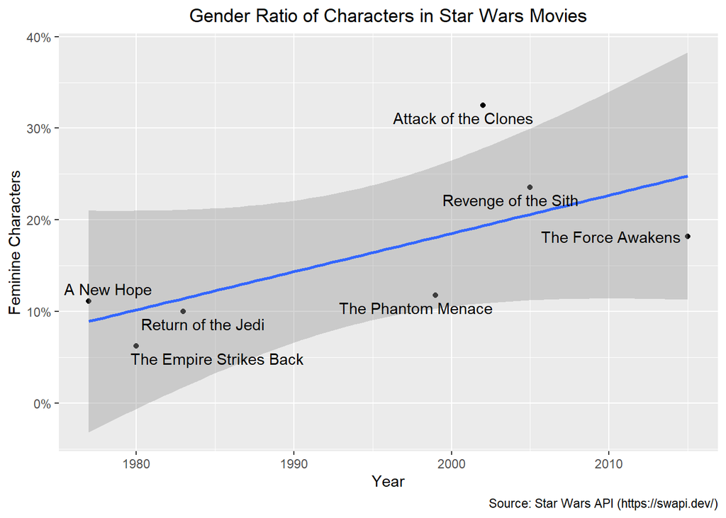

   ```r
   release <- tribble(
    ~movie, ~year,
    "A New Hope", 1977,
    "The Empire Strikes Back", 1980,
    "Return of the Jedi", 1983,
    "The Phantom Menace", 1999,
    "Attack of the Clones", 2002,
    "Revenge of the Sith", 2005,
    "The Force Awakens", 2015
      )

      perc_year <- left_join(feminine_perc, release, by = c("films" = "movie"))

      ggplot(perc_year, aes(year, percentage)) +
    geom_point() +
    geom_smooth(
      formula = y ~ x,
      method = "lm"
    ) +
    labs(
      title = "Gender Ratio of Characters in Star Wars Movies",
      x = "Year",
      y = "Feminine Characters",
      caption = "Source: Star Wars API (https://swapi.dev/)"
    ) +
    geom_text_repel(
      aes(label = films)
    ) +
    scale_y_continuous(
      breaks = seq(0, 0.4, 0.1),
      labels = scales::percent_format(accuracy = 5)
    ) +
    theme(plot.title = element_text(hjust = 0.5))
   ```

6. Briefly comment on the plot